# Week 4 Assignment: Building Regression Models with the mtcars Dataset

## Instructions

You work for Motor Trend, a magazine about the automobile industry. Looking at a data set of a collection of cars, they are interested in exploring the relationship between a set of variables and miles per gallon (MPG) (outcome). They are particularly interested in the following two questions:

1. Is an automatic or manual transmission better for MPG
2. Quantify the MPG difference between automatic and manual transmissions

## Data

```r
data("mtcars")
```

## Analysis

### Environment setup

```r
library(ggplot2)
library(dplyr)
```

### Exploratory Data Analyses

Since the main interest is to understand the relationship between transmission and MPG, isolate the two variables for exploratory data analysis

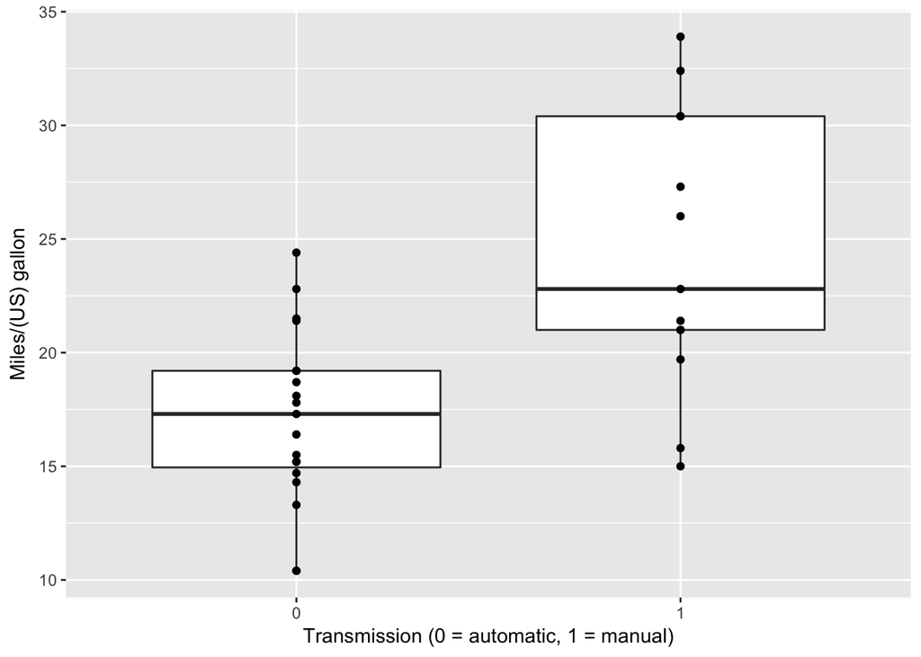

```r
mpgAm <- mtcars %>% select(mpg, am) %>% mutate(am = as.factor(am))
ggplot(data = mpgAm, aes(x = am, y = mpg)) +
  geom_boxplot() + geom_point() +
  xlab('Transmission (0 = automatic, 1 = manual)') +
  ylab('Miles/(US) gallon')
```

From the box plot, it seems that manual transmission has higher mean of miles per gallon.

### Fitting Models and Model Selection

First fit all variables to mpg and look at the diagnostics to decide which ones to remove (set type-I error at 5%)

```r
raw <- mtcars %>% mutate(cyl = as.factor(cyl), vs = as.factor(vs), am = as.factor(am), gear = as.factor(gear), carb = as.factor(carb))
fitAll <- lm(mpg ~ ., data = raw)
summary(fitAll)$coef[, 4]
```

```
## (Intercept)        cyl6        cyl8        disp          hp        drat
##  0.25252548  0.39746642  0.96317000  0.28267339  0.09393155  0.64073922
##          wt        qsec         vs1         am1       gear4       gear5
##  0.09461859  0.69966720  0.51150791  0.71131573  0.77332027  0.50889747
##       carb2       carb3       carb4       carb6       carb8
##  0.67865093  0.49546781  0.80956031  0.49381268  0.39948495
```

None of the coefficients has a p-value less than 5% in the full model, indicateing that variables should be selected - by slowly removing the most insignificant variables and refitting each time

```r
which.max(summary(fitAll)$coef[, 4]) #the cyl variable (cyl8 is the least significant)
```

```
## cyl8
##    3
```

```r
fitRaw <- raw %>% select(-cyl); fitRm <- lm(mpg ~ ., data = fitRaw); summary(fitRm)$coef[, 4]
```

```
## (Intercept)        disp          hp        drat          wt        qsec
##   0.4158127   0.2145504   0.1357694   0.2914041   0.1020825   0.5372086
##         vs1         am1       gear4       gear5       carb2       carb3
##   0.5622658   0.4964455   0.8004203   0.5903340   0.7423912   0.5839796
##       carb4       carb6       carb8
##   0.7337118   0.8632349   0.6856502
```

Again, there are no coefficients with a significant p-value after removing the cyl variable. The next most insignificant varible is removed and this process is repeated until all coefficients are significant

```r
#which.max(summary(fitRm)$coef[, 4]) #the carb variable
fitRaw <- fitRaw %>% select(-carb); fitRm <- lm(mpg ~ ., data = fitRaw)
#summary(fitRm)$coef[, 4]; which.max(summary(fitRm)$coef[, 4]) #the gear variable
fitRaw <- fitRaw %>% select(-gear); fitRm <- lm(mpg ~ ., data = fitRaw)
#summary(fitRm)$coef[, 4]; which.max(summary(fitRm)$coef[, 4]) #the vs variable
fitRaw <- fitRaw %>% select(-vs); fitRm <- lm(mpg ~ ., data = fitRaw)
#summary(fitRm)$coef[, 4]; which.max(summary(fitRm)$coef[, 4]) #the drat variable
fitRaw <- fitRaw %>% select(-drat); fitRm <- lm(mpg ~ ., data = fitRaw)
#summary(fitRm)$coef[, 4]; which.max(summary(fitRm)$coef[, 4]) #the disp variable
fitRaw <- fitRaw %>% select(-disp); fitRm <- lm(mpg ~ ., data = fitRaw)
#summary(fitRm)$coef[, 4]; which.max(summary(fitRm)$coef[, 4]) #the hp variable
fitRaw <- fitRaw %>% select(-hp); fitRm <- lm(mpg ~ ., data = fitRaw)
summary(fitRm)$coef[, 4]
```

```
##  (Intercept)           wt         qsec          am1
## 1.779152e-01 6.952711e-06 2.161737e-04 4.671551e-02
```

Finally, after removing all the variables with insignificant p-values, three coefficients, wt (wieght of 1000 lbs), qseq (1/4 mile time), and am (Transmission), have p-values less than 0.05. The porperties of this model is further explored

```r
summary(fitRm)
```

```
##
## Call:
## lm(formula = mpg ~ ., data = fitRaw)
##
## Residuals:
##     Min      1Q  Median      3Q     Max
## -3.4811 -1.5555 -0.7257  1.4110  4.6610
##
## Coefficients:
##             Estimate Std. Error t value Pr(>|t|)
## (Intercept)   9.6178     6.9596   1.382 0.177915
## wt           -3.9165     0.7112  -5.507 6.95e-06 ***
## qsec          1.2259     0.2887   4.247 0.000216 ***
## am1           2.9358     1.4109   2.081 0.046716 *
## ---
## Signif. codes:  0 '***' 0.001 '**' 0.01 '*' 0.05 '.' 0.1 ' ' 1
##
## Residual standard error: 2.459 on 28 degrees of freedom
## Multiple R-squared:  0.8497, Adjusted R-squared:  0.8336
## F-statistic: 52.75 on 3 and 28 DF,  p-value: 1.21e-11
```

### Diagnostics

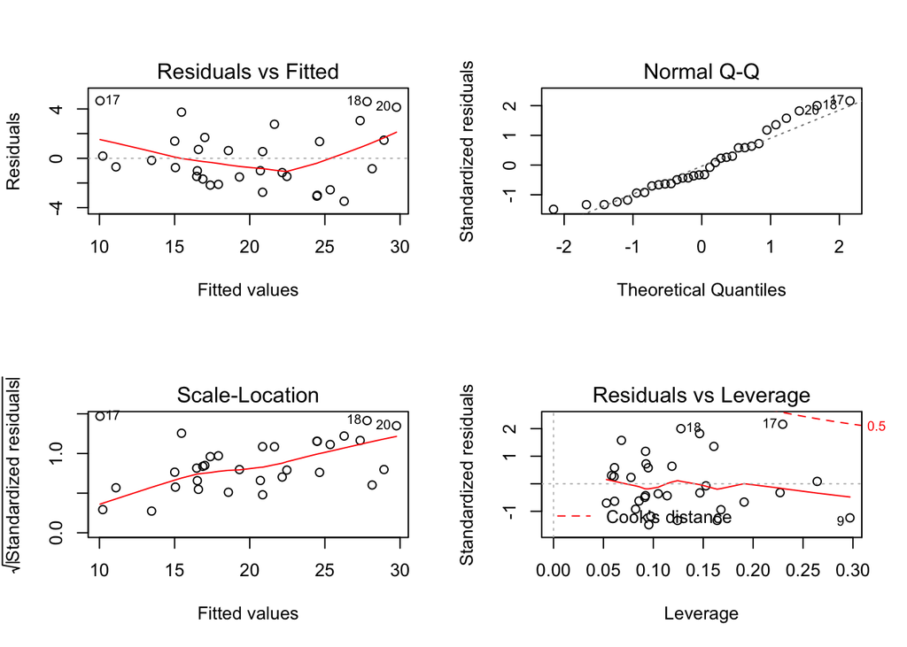

```r
par(mfrow = c(2, 2))
plot(fitRm)
```

## Conclusions

Going back to the questions: understanding the relationship between transmission and mpg. From the model, we can conclude that when the weight and 1/4 mile time are the same for two cars, and one is an automatic and the other manual, the manual one will have an average of 2.9358 higher miles/gallon than the automatic car. Perhaps that’s why a lot of race cars are manual?